# Lezione 1 — Demo R

MAF, HWE e LD su chr10 di 1000 Genomes

Statistical Models for Genetics

Master in Biostatistica

# Premessa operativa

Questa demo è lo scheletro che rifaremo sul dataset reale T2D / chr10 di 1000 Genomes. Per renderla auto-contenuta e renderizzabile ovunque, qui generiamo un **piccolo dataset sintetico** che imita la struttura del dato reale (1000G chr10, ~2.500 individui, ~2 milioni di SNP). Nel laboratorio basterà sostituire la sezione “Caricamento dati” con il path al file PLINK vero che vi verrà fornito — il resto del codice resta identico.

**Pacchetti utilizzati nel laboratorio reale:**

- `genio` — lettura di file PLINK in R
- `snpStats` — ispezione, MAF, HWE
- `LDheatmap` — visualizzazione LD
- `ggplot2` + `dplyr` — manipolazione e grafici

In questa demo, **simuliamo** la matrice di genotipi direttamente in R, così non servono dipendenze esterne pesanti per la renderizzazione delle slide.

```r
library(ggplot2)
library(dplyr)
library(tidyr)
theme_set(theme_minimal(base_size = 13))
```

# 1. Caricamento dei dati (versione lab vs versione demo)

## Versione **lab reale**

Nel laboratorio con i dati reali i dati vanno caricati così:

```r
# --- Lab reale: dati T2D 1000G chr10 ---
library(genio)
plink_path <- "data/T2D_chr10"   # path del trio .bed/.bim/.fam
dat        <- read_plink(plink_path)
G          <- dat$X              # matrice n_snp × n_ind di {0, 1, 2, NA}
bim        <- dat$bim            # info per-SNP
fam        <- dat$fam            # info per-individuo
```

## Versione **demo** (auto-contenuta)

Qui simuliamo una matrice di genotipi realistica:

- 1.000 individui (vs ~2.500 nel dato reale)
- 5.000 SNP su una “finestra di chr10” intorno a TCF7L2 (vs ~2M sul cromosoma intero)
- frequenze alleliche distribuite come in popolazioni europee
- iniettiamo un **blocco di LD** centrato su rs7903146 (TCF7L2)

```r
n_ind <- 1000
n_snp <- 5000

# Frequenze alleliche realistiche: mistura di SNP comuni e a bassa frequenza
maf_true <- c(
  runif(n_snp * 0.7, 0.05, 0.50),  # 70% comuni
  runif(n_snp * 0.2, 0.01, 0.05),  # 20% a bassa frequenza
  runif(n_snp * 0.1, 0.001, 0.01)  # 10% rare
)
maf_true <- sample(maf_true, n_snp)

# Posizioni simulate su chr10 (regione ~114.7-114.8 Mb intorno a TCF7L2)
pos <- sort(round(runif(n_snp, 114000000, 115500000)))

# Genotipi: binomiale(2, p) per ogni SNP (HWE perfetto)
G <- matrix(NA_integer_, nrow = n_ind, ncol = n_snp)
for (j in seq_len(n_snp)) {
  G[, j] <- rbinom(n_ind, size = 2, prob = maf_true[j])
}

# rownames e colnames realistici
rownames(G) <- sprintf("HG%05d", seq_len(n_ind))
colnames(G) <- sprintf("rs%07d", seq_len(n_snp))

# Iniettiamo un blocco LD intorno a una posizione "TCF7L2-like"
tcf7l2_idx     <- which.min(abs(pos - 114758349))
tcf7l2_rsid    <- colnames(G)[tcf7l2_idx]
ld_block_idx   <- (tcf7l2_idx - 25):(tcf7l2_idx + 25)
ld_block_idx   <- ld_block_idx[ld_block_idx >= 1 & ld_block_idx <= n_snp]

# Per gli SNP nel blocco, ricopio il segnale di TCF7L2 con rumore decrescente
# → genera LD r² alta sotto i 50 kb
for (j in ld_block_idx) {
  if (j == tcf7l2_idx) next
  dist_units <- abs(j - tcf7l2_idx)
  noise_p    <- 0.5 * (1 - exp(-dist_units / 8))  # 0% rumore al centro, ~50% al bordo
  swap       <- rbinom(n_ind, 1, noise_p) == 1
  G[, j]     <- ifelse(swap, rbinom(n_ind, 2, maf_true[j]), G[, tcf7l2_idx])
}

# Rinomino il SNP centrale per chiarezza didattica
colnames(G)[tcf7l2_idx] <- "rs7903146"
tcf7l2_rsid <- "rs7903146"

# Tabelle .bim e .fam simulate per coerenza con il lab reale
bim <- data.frame(
  chr  = 10L,
  rsID = colnames(G),
  cM   = 0,
  pos  = pos,
  A1   = "T",
  A2   = "C",
  stringsAsFactors = FALSE
)

fam <- data.frame(
  FID   = rownames(G),
  IID   = rownames(G),
  pat   = 0,
  mat   = 0,
  sex   = sample(1:2, n_ind, replace = TRUE),
  pheno = sample(1:2, n_ind, replace = TRUE),
  stringsAsFactors = FALSE
)

dim(G)
```

```
## [1] 1000 5000
```

# 2. Ispezione di `.bim` e `.fam`

## `.bim` — informazioni per-SNP

```r
head(bim, 10)
```

|  | chr | rsID | cM | pos | A1 | A2 |
| --- | --- | --- | --- | --- | --- | --- |
| 1 | 10 | rs0000001 | 0 | 114000469 | T | C |
| 2 | 10 | rs0000002 | 0 | 114000899 | T | C |
| 3 | 10 | rs0000003 | 0 | 114001143 | T | C |
| 4 | 10 | rs0000004 | 0 | 114001675 | T | C |
| 5 | 10 | rs0000005 | 0 | 114001851 | T | C |
| 6 | 10 | rs0000006 | 0 | 114002070 | T | C |
| 7 | 10 | rs0000007 | 0 | 114002185 | T | C |
| 8 | 10 | rs0000008 | 0 | 114002208 | T | C |
| 9 | 10 | rs0000009 | 0 | 114002228 | T | C |
| 10 | 10 | rs0000010 | 0 | 114002539 | T | C |

**Cosa stiamo guardando**: ogni riga è uno SNP. Le colonne sono cromosoma, identificativo (rsID), distanza in centiMorgan (di solito 0), posizione fisica in basi, e i due alleli (A1 = di solito l’allele *alternativo*, A2 = il *reference*).

**Domanda:** *“questa è la regione di TCF7L2 — sapete riconoscere la posizione canonica di rs7903146?”*

```r
bim[bim$rsID == "rs7903146", ]
```

|  | chr | rsID | cM | pos | A1 | A2 |
| --- | --- | --- | --- | --- | --- | --- |
| 2513 | 10 | rs7903146 | 0 | 114758294 | T | C |

## `.fam` — informazioni per-individuo

```r
head(fam, 10)
```

|  | FID | IID | pat | mat | sex | pheno |
| --- | --- | --- | --- | --- | --- | --- |
| 1 | HG00001 | HG00001 | 0 | 0 | 2 | 2 |
| 2 | HG00002 | HG00002 | 0 | 0 | 1 | 1 |
| 3 | HG00003 | HG00003 | 0 | 0 | 1 | 2 |
| 4 | HG00004 | HG00004 | 0 | 0 | 1 | 2 |
| 5 | HG00005 | HG00005 | 0 | 0 | 2 | 1 |
| 6 | HG00006 | HG00006 | 0 | 0 | 1 | 1 |
| 7 | HG00007 | HG00007 | 0 | 0 | 2 | 1 |
| 8 | HG00008 | HG00008 | 0 | 0 | 1 | 2 |
| 9 | HG00009 | HG00009 | 0 | 0 | 1 | 1 |
| 10 | HG00010 | HG00010 | 0 | 0 | 1 | 1 |

**Codifica del fenotipo (caso-controllo):**

- `1` = controllo
- `2` = caso
- `-9` o `0` = mancante

**Distribuzione casi/controlli nel nostro dataset:**

```r
table(fam$pheno, dnn = "pheno")
```

```
## pheno
##   1   2
## 492 508
```

(Per ora il fenotipo è simulato in modo *neutro*. Il segnale T2D verrà iniettato nel dataset reale del laboratorio.)

# 3. Frequenze alleliche e MAF

La frequenza dell’allele alternativo è la **media della colonna di $G$ divisa per 2**:

```r
# Frequenza dell'allele alternativo
freq_alt <- colMeans(G, na.rm = TRUE) / 2

# MAF = min(p, 1-p)
maf <- pmin(freq_alt, 1 - freq_alt)

summary(maf)
```

```
##    Min. 1st Qu.  Median    Mean 3rd Qu.    Max.
##  0.0000  0.0405  0.1815  0.2011  0.3410  0.5000
```

## Spettro delle frequenze alleliche

Lo spettro è il grafico più informativo di un dataset GWAS: ci dice **quanti SNP comuni** abbiamo e dove si concentra la massa.

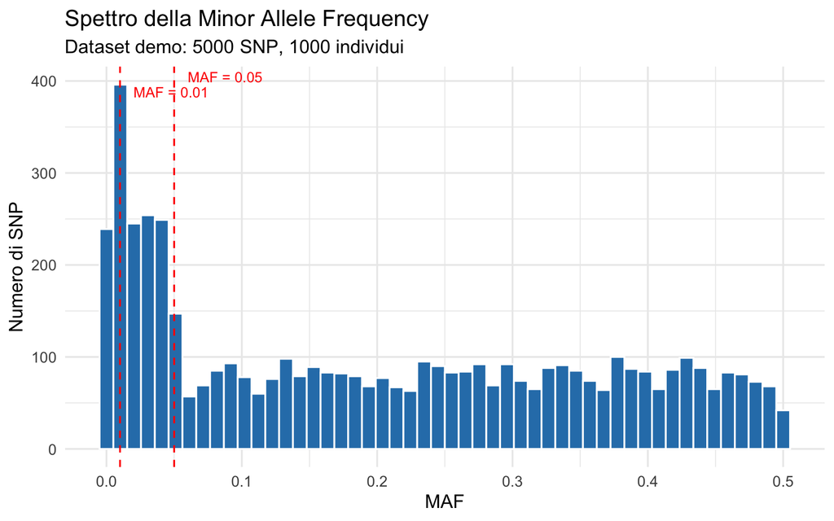

Spettro della MAF: ~70% degli SNP sono comuni (MAF ≥ 0.05)

```r
library(ggplot2)
ggplot(data.frame(maf = maf), aes(x = maf)) +
  geom_histogram(bins = 50, fill = "#2c7fb8", color = "white") +
  geom_vline(xintercept = c(0.01, 0.05), linetype = "dashed", color = "red") +
  annotate("text", x = 0.06, y = Inf, label = "MAF = 0.05",
           color = "red", vjust = 1.5, hjust = 0, size = 3.5) +
  annotate("text", x = 0.02, y = Inf, label = "MAF = 0.01",
           color = "red", vjust = 3, hjust = 0, size = 3.5) +
  labs(
    x = "MAF", y = "Numero di SNP",
    title = "Spettro della Minor Allele Frequency",
    subtitle = paste0("Dataset demo: ", n_snp, " SNP, ", n_ind, " individui")
  )
```

## Tabella riassuntiva per categoria

```r
maf_class <- cut(maf,
  breaks = c(-Inf, 0.01, 0.05, 0.5),
  labels = c("rare (<1%)", "bassa freq. (1-5%)", "comuni (≥5%)")
)
table(maf_class)
```

```
## maf_class
##         rare (<1%) bassa freq. (1-5%)       comuni (≥5%)
##                485                977               3538
```

# 4. Equilibrio di Hardy–Weinberg

## Calcolo manuale del test χ² (un solo SNP)

Riprendiamo il SNP TCF7L2 (rs7903146) e calcoliamo HWE *a mano*, per fissare l’algebra:

```r
g     <- G[, "rs7903146"]
n     <- sum(!is.na(g))

# Conteggi genotipici osservati
o_AA  <- sum(g == 0, na.rm = TRUE)
o_Aa  <- sum(g == 1, na.rm = TRUE)
o_aa  <- sum(g == 2, na.rm = TRUE)

# Frequenza allelica
p     <- (2 * o_AA + o_Aa) / (2 * n)
q     <- 1 - p

# Frequenze attese sotto HWE
e_AA  <- n * p^2
e_Aa  <- n * 2 * p * q
e_aa  <- n * q^2

# Statistica χ²
X2    <- (o_AA - e_AA)^2 / e_AA +
         (o_Aa - e_Aa)^2 / e_Aa +
         (o_aa - e_aa)^2 / e_aa

p_val <- pchisq(X2, df = 1, lower.tail = FALSE)

data.frame(
  conteggio  = c("AA", "Aa", "aa", "n", "p", "X²", "p-value"),
  osservato  = c(o_AA, o_Aa, o_aa, n, "", "", ""),
  atteso_HWE = c(round(e_AA,1), round(e_Aa,1), round(e_aa,1), n,
                 round(p,3), round(X2,3), formatC(p_val, digits = 3))
)
```

| conteggio | osservato | atteso_HWE |
| --- | --- | --- |
| AA | 586 | 576.8 |
| Aa | 347 | 365.3 |
| aa | 67 | 57.8 |
| n | 1000 | 1000 |
| p |  | 0.759 |
| X² |  | 2.515 |
| p-value |  | 0.113 |

## Calcolo vettorializzato su tutti gli SNP

```r
# Funzione per HWE p-value su un vettore di genotipi {0,1,2,NA}
hwe_test <- function(g) {
  g <- g[!is.na(g)]
  n <- length(g)
  if (n < 50) return(NA_real_)  # troppo pochi dati
  o_AA <- sum(g == 0); o_Aa <- sum(g == 1); o_aa <- sum(g == 2)
  p <- (2 * o_AA + o_Aa) / (2 * n)
  q <- 1 - p
  if (p == 0 || q == 0) return(NA_real_)
  e_AA <- n * p^2; e_Aa <- n * 2 * p * q; e_aa <- n * q^2
  X2 <- (o_AA - e_AA)^2 / e_AA +
        (o_Aa - e_Aa)^2 / e_Aa +
        (o_aa - e_aa)^2 / e_aa
  pchisq(X2, df = 1, lower.tail = FALSE)
}

# Applichiamo a tutti gli SNP (sono 5000)
hwe_p <- apply(G, 2, hwe_test)

summary(hwe_p)
```

```
##    Min. 1st Qu.  Median    Mean 3rd Qu.    Max.    NA's
##  0.0000  0.2736  0.5475  0.5281  0.7874  1.0000       3
```

## Distribuzione dei p-value di HWE

Sotto $H_0$ (HWE vale ovunque) i p-value sono **uniformi su [0, 1]**.

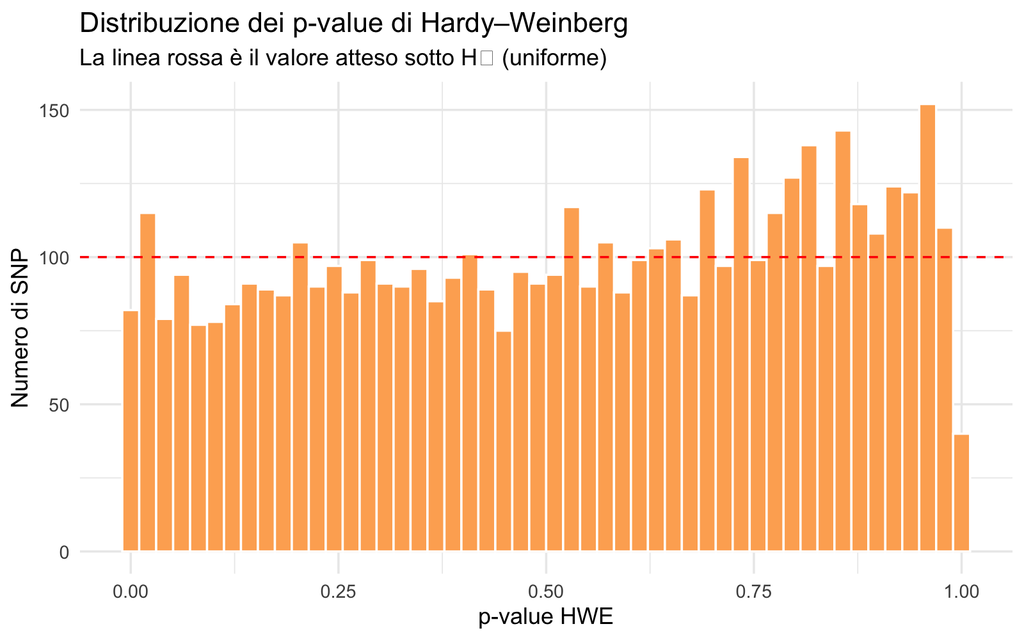

P-value HWE: distribuzione uniforme attesa sotto H₀

```r
ggplot(data.frame(p = hwe_p), aes(x = p)) +
  geom_histogram(bins = 50, fill = "#fdae61", color = "white") +
  geom_hline(yintercept = n_snp / 50, linetype = "dashed", color = "red") +
  labs(
    x = "p-value HWE", y = "Numero di SNP",
    title = "Distribuzione dei p-value di Hardy–Weinberg",
    subtitle = "La linea rossa è il valore atteso sotto H₀ (uniforme)"
  )
```

**Interpretazione:**

- distribuzione **piatta** sotto $H_0$ ⇒ il dataset è “pulito” dal punto di vista di HWE
- un **eccesso vicino a 0** indicherebbe presenza di errori sistematici di genotipizzazione
- nel dato reale T2D *noisy* (L2) vedremo questo eccesso e lo useremo come filtro

## Quanti SNP filtreremmo a $p < 10^{-6}$?

Soglia GWAS standard:

```r
sum(hwe_p < 1e-6, na.rm = TRUE)
```

```
## [1] 4
```

Con un dataset simulato pulito ne aspettiamo praticamente zero. Nel dato reale T2D ne vedremo qualche centinaio — ed è esattamente quello che il filtro HWE serve a togliere.

# 5. Linkage Disequilibrium

## Calcolo di r² tra due SNP

Definizione operativa: $r^2$ è il **quadrato della correlazione di Pearson** tra le due colonne di genotipi.

```r
# Prendiamo TCF7L2 e uno SNP vicino
snp1 <- G[, "rs7903146"]
snp2 <- G[, tcf7l2_idx + 1]  # SNP immediatamente adiacente

r  <- cor(snp1, snp2, use = "pairwise.complete.obs")
r2 <- r^2

cat(sprintf("r²(rs7903146, SNP vicino) = %.3f\n", r2))
```

```
## r²(rs7903146, SNP vicino) = 0.868
```

**Sanity check:** dato che abbiamo iniettato LD forte nel blocco, ci aspettiamo $r^2$ alto qui — e infatti.

## Decadimento di r² con la distanza

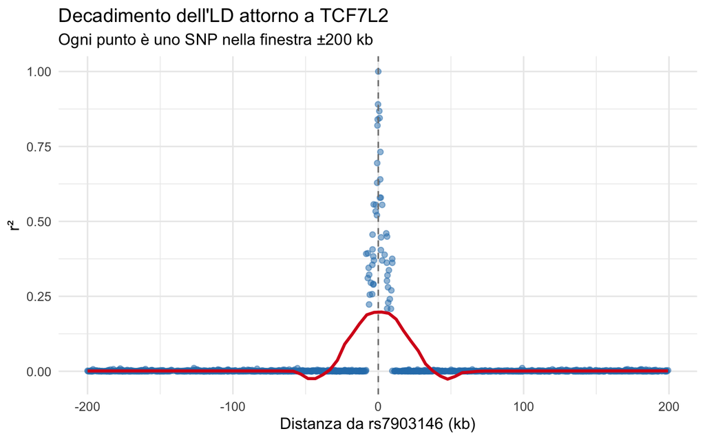

Decadimento dell’LD attorno a TCF7L2 (rs7903146)

```r
# Distanze (in basi) di tutti gli SNP nella regione TCF7L2 ± 200kb
center_pos <- bim$pos[bim$rsID == "rs7903146"]
window_idx <- which(abs(bim$pos - center_pos) <= 200000)
window_pos <- bim$pos[window_idx]

# r² di ogni SNP nella finestra rispetto a rs7903146
r2_window <- sapply(window_idx, function(j) {
  if (colnames(G)[j] == "rs7903146") return(1)
  r <- cor(G[, "rs7903146"], G[, j], use = "pairwise.complete.obs")
  r^2
})

ld_df <- data.frame(
  dist_kb = (window_pos - center_pos) / 1000,
  r2      = r2_window
)

ggplot(ld_df, aes(x = dist_kb, y = r2)) +
  geom_point(alpha = 0.5, color = "#2c7fb8") +
  geom_smooth(method = "loess", span = 0.3, color = "#d7191c", se = FALSE) +
  geom_vline(xintercept = 0, linetype = "dashed", color = "grey50") +
  labs(
    x = "Distanza da rs7903146 (kb)", y = "r²",
    title = "Decadimento dell'LD attorno a TCF7L2",
    subtitle = "Ogni punto è uno SNP nella finestra ±200 kb"
  )
```

## LD heatmap della regione TCF7L2

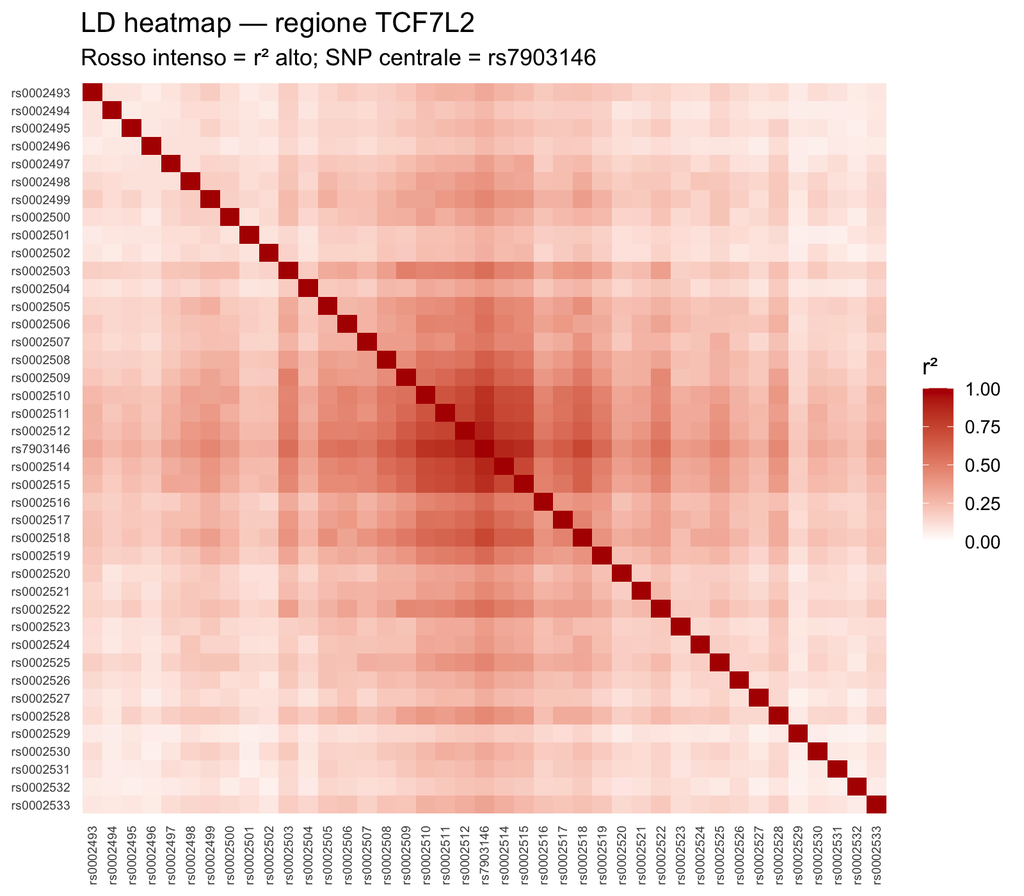

```r
# Selezioniamo gli SNP del blocco
heatmap_idx <- (tcf7l2_idx - 20):(tcf7l2_idx + 20)
heatmap_idx <- heatmap_idx[heatmap_idx >= 1 & heatmap_idx <= n_snp]
G_heat      <- G[, heatmap_idx]
labels_heat <- colnames(G_heat)

# Matrice di r² pairwise
n_h <- length(heatmap_idx)
ld_mat <- matrix(NA_real_, n_h, n_h)
for (i in 1:n_h) for (j in 1:n_h) {
  ld_mat[i, j] <- cor(G_heat[, i], G_heat[, j], use = "pairwise.complete.obs")^2
}
rownames(ld_mat) <- colnames(ld_mat) <- labels_heat

# Plot con ggplot
ld_long <- as.data.frame(as.table(ld_mat))
colnames(ld_long) <- c("SNP1", "SNP2", "r2")
ld_long$SNP1 <- factor(ld_long$SNP1, levels = labels_heat)
ld_long$SNP2 <- factor(ld_long$SNP2, levels = rev(labels_heat))

ggplot(ld_long, aes(x = SNP1, y = SNP2, fill = r2)) +
  geom_tile() +
  scale_fill_gradient(low = "white", high = "#b30000",
                      limits = c(0, 1), name = "r²") +
  theme(
    axis.text.x = element_text(angle = 90, hjust = 1, vjust = 0.5, size = 7),
    axis.text.y = element_text(size = 7),
    panel.grid  = element_blank()
  ) +
  labs(
    x = NULL, y = NULL,
    title = "LD heatmap — regione TCF7L2",
    subtitle = "Rosso intenso = r² alto; SNP centrale = rs7903146"
  )
```

- il **quadrato rosso centrale** identifica il blocco aplotipico TCF7L2
- gli SNP **fuori dal blocco** (angoli) sono bianchi → indipendenti
- nel laboratorio, faremo la stessa cosa con `LDheatmap::LDheatmap()` che produce un grafico più curato

# 6. Identificare rs7903146 — il top SNP T2D

Riassumiamo cosa sappiamo di **rs7903146** dopo questa lezione:

```r
g <- G[, "rs7903146"]
data.frame(
  metrica = c(
    "Posizione (chr10)",
    "MAF",
    "n_AA (omozigote ref)",
    "n_Aa (eterozigote)",
    "n_aa (omozigote alt)",
    "HWE p-value",
    "SNP in r² ≥ 0.8 nella regione"
  ),
  valore = c(
    format(bim$pos[bim$rsID == "rs7903146"], big.mark = ","),
    round(maf["rs7903146"], 3),
    sum(g == 0, na.rm = TRUE),
    sum(g == 1, na.rm = TRUE),
    sum(g == 2, na.rm = TRUE),
    formatC(hwe_p["rs7903146"], digits = 3, format = "g"),
    sum(r2_window >= 0.8) - 1  # esclusione di sé stesso
  )
)
```

| metrica | valore |
| --- | --- |
| Posizione (chr10) | 114,758,294 |
| MAF | 0.24 |
| n_AA (omozigote ref) | 586 |
| n_Aa (eterozigote) | 347 |
| n_aa (omozigote alt) | 67 |
| HWE p-value | 0.113 |
| SNP in r² ≥ 0.8 nella regione | 5 |

# Appendice — Comandi rapidi da ricordare

| Operazione | Codice |
| --- | --- |
| Caricare PLINK | `dat <- genio::read_plink("T2D_chr10")` |
| Estrarre matrice genotipi | `G <- dat$X` (n_snp × n_ind) |
| Frequenza allele ALT | `freq <- colMeans(G, na.rm = TRUE) / 2` |
| MAF | `maf <- pmin(freq, 1 - freq)` |
| HWE p-value (singolo SNP) | vedi funzione `hwe_test` qui sopra |
| LD pairwise r² | `cor(G[,i], G[,j], use="pairwise.complete.obs")^2` |
| LD heatmap pronta | `LDheatmap::LDheatmap(snpStats_matrix)` |

**Tutta la pipeline GWAS è una sequenza di operazioni su questa matrice `G`.** Da qui partiremo per tutto il resto del corso.